# Predicting bankruptcy in the telecommunications industry

Hailey Yim

2024-04-15

## Variable Selection Analysis

### Import data

```r
set.seed(1234)
bankruptcy = read.table("bankruptcy.dat",sep="\t",header=T,row.names=NULL)
attach(bankruptcy)

#remove first column (company)
bankruptcy=bankruptcy[,-1]
head(bankruptcy)
```

```
##   WC.TA  RE.TA EBIT.TA S.TA BVE.BVL Bankrupt
## 1   9.3   -7.7     1.6  9.1   3.726        1
## 2  42.6  -60.1   -10.1  0.3   4.130        1
## 3 -28.8 -203.2   -51.0 14.7   0.111        1
## 4   2.5 -433.1    -6.0 29.3   1.949        1
## 5  26.1  -57.4   -23.5 54.2   0.855        1
## 6  39.2 -111.8   -77.8 10.5   0.168        1
```

### Boxplots and correlation

```
##                WC.TA       RE.TA     EBIT.TA        S.TA     BVE.BVL
## WC.TA     1.00000000  0.31506639 -0.00409731 -0.16413893  0.11369197
## RE.TA     0.31506639  1.00000000  0.54856602  0.13337470  0.06595416
## EBIT.TA  -0.00409731  0.54856602  1.00000000  0.08407904  0.07058227
## S.TA     -0.16413893  0.13337470  0.08407904  1.00000000 -0.05426599
## BVE.BVL   0.11369197  0.06595416  0.07058227 -0.05426599  1.00000000
## Bankrupt -0.24165361 -0.59877718 -0.59937756  0.01669244 -0.27903476
##             Bankrupt
## WC.TA    -0.24165361
## RE.TA    -0.59877718
## EBIT.TA  -0.59937756
## S.TA      0.01669244
## BVE.BVL  -0.27903476
## Bankrupt  1.00000000
```

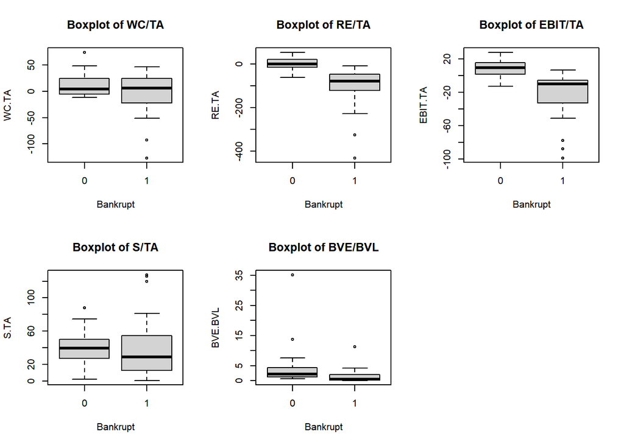

```r
par(mfrow=c(2,3))
boxplot(split(WC.TA,Bankrupt),style.bxp="old",xlab="Bankrupt",ylab="WC.TA",main="Boxplot of WC/TA")
boxplot(split(RE.TA,Bankrupt),style.bxp="old",xlab="Bankrupt",ylab="RE.TA",main="Boxplot of RE/TA")
boxplot(split(EBIT.TA,Bankrupt),style.bxp="old",xlab="Bankrupt",ylab="EBIT.TA",main="Boxplot of EBIT/TA")
boxplot(split(S.TA,Bankrupt),style.bxp="old",xlab="Bankrupt",ylab="S.TA",main="Boxplot of S/TA")
boxplot(split(BVE.BVL,Bankrupt),style.bxp="old",xlab="Bankrupt",ylab="BVE.BVL",main="Boxplot of BVE/BVL")

cor(bankruptcy)
```

*Correlation coefficients can range from -1 to 1.*

*- Values close to 1: Strong positive linear relationship.*

*- Values close to -1: Strong negative linear relationship.*

*- Values close to 0: No linear relationship*

**Correlation between variables:**

### Fit full model vs reduced model (before outlier removal) for AIC, BIC comparison

- **Deviance Residuals:** measure of model fit (difference between the observed response and the fitted values from the model)
- **Null Deviance:** the deviance of the null model, which is the model with no predictor variables.
- **Residual Deviance:** the deviance of the fitted model. A lower residual deviance indicates a better fit to the data.
- **AIC:** a measure of the model’s goodness of fit that penalizes model complexity. Lower AIC values indicate better fitting models.

```r
set.seed(1234)

#Full
bank1 = glm(Bankrupt ~ ., data=bankruptcy,family='binomial',maxit=500)
summary(bank1)
```

```
##
## Call:
## glm(formula = Bankrupt ~ ., family = "binomial", data = bankruptcy,
##     maxit = 500)
##
## Deviance Residuals:
##      Min        1Q    Median        3Q       Max
## -1.14853  -0.06248   0.00000   0.00039   2.35010
##
## Coefficients:
##             Estimate Std. Error z value Pr(>|z|)
## (Intercept)  7.42646    6.35770   1.168    0.243
## WC.TA       -0.15587    0.12208  -1.277    0.202
## RE.TA       -0.07605    0.06311  -1.205    0.228
## EBIT.TA     -0.49111    0.32260  -1.522    0.128
## S.TA        -0.08040    0.09216  -0.872    0.383
## BVE.BVL     -2.07764    1.47488  -1.409    0.159
##
## (Dispersion parameter for binomial family taken to be 1)
##
##     Null deviance: 69.315  on 49  degrees of freedom
## Residual deviance: 11.847  on 44  degrees of freedom
## AIC: 23.847
##
## Number of Fisher Scoring iterations: 11
```

```r
#Reduced
bank2 = glm(Bankrupt ~.-WC.TA, data=bankruptcy,family='binomial',maxit=500)
summary(bank2)
```

```
##
## Call:
## glm(formula = Bankrupt ~ . - WC.TA, family = "binomial", data = bankruptcy,
##     maxit = 500)
##
## Deviance Residuals:
##      Min        1Q    Median        3Q       Max
## -1.79310  -0.16838  -0.00002   0.06636   2.20656
##
## Coefficients:
##             Estimate Std. Error z value Pr(>|z|)
## (Intercept)  0.16064    1.72749   0.093   0.9259
## RE.TA       -0.05634    0.02801  -2.011   0.0443 *
## EBIT.TA     -0.17244    0.09935  -1.736   0.0826 .
## S.TA        -0.01092    0.03040  -0.359   0.7195
## BVE.BVL     -0.68759    0.44972  -1.529   0.1263
## ---
## Signif. codes:  0 '***' 0.001 '**' 0.01 '*' 0.05 '.' 0.1 ' ' 1
##
## (Dispersion parameter for binomial family taken to be 1)
##
##     Null deviance: 69.315  on 49  degrees of freedom
## Residual deviance: 15.757  on 45  degrees of freedom
## AIC: 25.757
##
## Number of Fisher Scoring iterations: 9
```